# ETC3250 Assignment 2

SOLUTION

## Exercises

1. This question is about the normal distribution, and how it relates to the classification rule provided by linear discriminant analysis.
1. (1)Write down the density function for a bivariate normal distribution ($p=2$), with mean $\mu_k$ and variance $\Sigma$.

$$f(x) = \frac{1}{2\pi|\Sigma|}\exp\{-\frac{1}{2}(x-\mu)'\Sigma^{-1}(x-\mu)\}$$
where $x=(x_1, x_2)$, $\mu=(\mu_1, \mu_2)$, $\Sigma=\left[ \begin{array}{cc} \sigma_1^2 & \rho\sigma_1\sigma_2 \\ \rho\sigma_1\sigma_2 & \sigma_2^2 \end{array} \right]$

2. (2)Show that the linear discriminant rule for two groups ($K=2$), $\pi_1=\pi_2$ and

$$\Sigma_1=\Sigma_2 = \Sigma = \left[\begin{array}{cc} \sigma_1^2 & \rho\sigma_1\sigma_2 \\ \rho\sigma_1\sigma_2 & \sigma_2^2 \end{array}\right]$$
where $\rho$ is the population correlation between the two variables, and $\sigma_1, \sigma_2$ are the population standard deviations of the two variables, respectively, is equal to: *Assign a new observation $x_0$ to group 1 if*
$$x_0'\Sigma^{-1}(\mu_1-\mu_2) > \frac{1}{2}(\mu_1 + \mu_2)'\Sigma^{-1}(\mu_1-\mu_2)$$
**The rule is to assign observation to the group with the highest probability, so work from the density functions for the tewo groups. Let**

$x=(x_1, x_2)$, $\mu_1=(\mu_{11}, \mu_{12})$, $\mu_2=(\mu_{21}, \mu_{22})$ **then**

$$\frac{1}{2\pi|\Sigma|}\exp\{-\frac{1}{2}(x-\mu_1)'\Sigma^{-1}(x-\mu_1)\}>\frac{1}{2\pi|\Sigma|}\exp\{-\frac{1}{2}(x-\mu_2)'\Sigma^{-1}(x-\mu_2)\}$$

$$\leadsto ~~~ (x-\mu_1)'\Sigma^{-1}(x-\mu_1) > (x-\mu_2)'\Sigma^{-1}(x-\mu_2)$$
$$\leadsto ~~~~~~~~~~~~~~~ x'\Sigma^{-1}x -x'\Sigma^{-1}\mu_1 - \mu_1'\Sigma^{-1}x+\mu_1'\Sigma^{-1}\mu_1 > x'\Sigma^{-1}x -x'\Sigma^{-1}\mu_2 - \mu_2'\Sigma^{-1}x+\mu_2'\Sigma^{-1}\mu_2$$
$$\leadsto ~~~~~~~~~~~~~~~~~~~~~~~~~~~~~~~~~~~~~~~-x'\Sigma^{-1}\mu_1 - \mu_1'\Sigma^{-1}x+\mu_1'\Sigma^{-1}\mu_1> -x'\Sigma^{-1}\mu_2 - \mu_2'\Sigma^{-1}x+\mu_2'\Sigma^{-1}\mu_2$$
$$\leadsto ~~~~~~~~~~~~~~~~~~~~~~~~~~~~~~~~~~~~~~~~~~x'\Sigma^{-1}\mu_1 +x'\Sigma^{-1}\mu_2 + \mu_1'\Sigma^{-1}x + \mu_2'\Sigma^{-1}x > - \mu_1'\Sigma^{-1}\mu_1 + \mu_2'\Sigma^{-1}\mu_2$$
$$\leadsto ~~~~~~~~~~~~~~~~~~~~~~~~~~~~~~~~~~~~~~~~~~~~~~~~~~~~~~~~~~~~~~~~~~~~~~~~~~~~~~2x'\Sigma^{-1}(\mu_1-\mu_2) > (\mu_1+\mu_2)'\Sigma^{-1}(\mu_1-\mu_2)$$
$$\leadsto ~~~~~~~~~~~~~~~~~~~~~~~~~~~~~~~~~~~~~~~~~~~~~~~~~~~~~~~~~~~~~~~~~~~~~~~~~~~x'\Sigma^{-1}(\mu_1-\mu_2) > \frac{1}{2}(\mu_1+\mu_2)'\Sigma^{-1}(\mu_1-\mu_2)$$
c. (2)By generating a grid of values, draw the boundary between two groups, in the 2D space. Use these values for $\mu_1, \mu_2$ and $\sigma$.
$$\mu_1 = \left[\begin{array}{r} -2 \\ 2 \end{array}\right], ~~~\mu_2 = \left[\begin{array}{r} 2 \\ -2 \end{array}\right]$$
$$\Sigma = \left[\begin{array}{rr} 4 & 3 \\ 3 & 5 \end{array}\right]$$

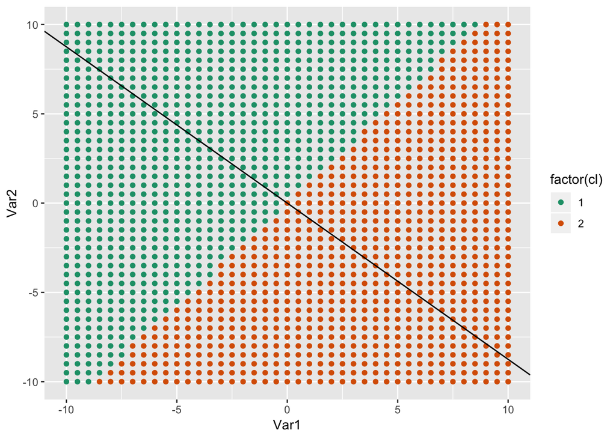

4. (2)Write down the rule using these parameter values, and sketch the line corresponding to the 1D discriminant space on the previous plot.

**Slope of the line corresponding to the discriminant space is given by** $\Sigma^{-1}(\mu_1-\mu_2)$.

$$\Sigma^{-1}(\mu_1-\mu_2) = 1/11\left[ \begin{array}{cc} 5 & -3 \\ -3 & 4 \end{array}\right] \left[\begin{array}{c} 4\\ -4 \end{array}\right]$$
**slope = -7/8. And run the line through (0,0) to fit into the plot above.**

**Rule is** *Assign x to class 2 if* $8/11x_1-7/11x_2>0$.

2. This question is about dimension reduction using PCA. We will use data from the world bank, on development indicators for 264 countries. Go to this site https://databank.worldbank.org/data/source/world-development-indicators/preview/on# to extract a copy of the data yourself. You should select all the countries that they have available, and just year 2017. There are some countries that are not countries, that you should exclude: “Upper middle income”, “Pre-demographic dividend”, “Post-demographic dividend”, “Other small states”, “OECD members”, “Not classified”, “Middle income”, “Lower middle income”, “Low income”, “Low & middle income”, “Least developed countries”, “UN classification”, “Late-demographic dividend”, “IDA & IBRD total”, “IDA blend”, “IDA only”, “IDA total”, “High income”, “Heavily indebted poor countries (HIPC)”, “Fragile and conflict affected situations”.

You will need to do some cleaning on the data.

1. Remove the two lines which are missing on the `Series Name`, and rename `2017 [YR2017]` to “value”.
2. Make a look up dictionary mapping `Series Code` to `Series Name`, so that we can do the analysis with the code (shorter), but refer back to the name as needed.
3. Spread the data into wide form, so that you have variables `Country Name`, `Country Code`, and the 55 `Series Name` variables as columns.
4. Using the `naniar` package make a missingness heatmap of the data
5. Remove any variable that is missing for more than 100 countries. Then, remove any countries that have missing on more than 2 variables.
6. Use $k$ nearest neighbours imputation to fill in the missings.

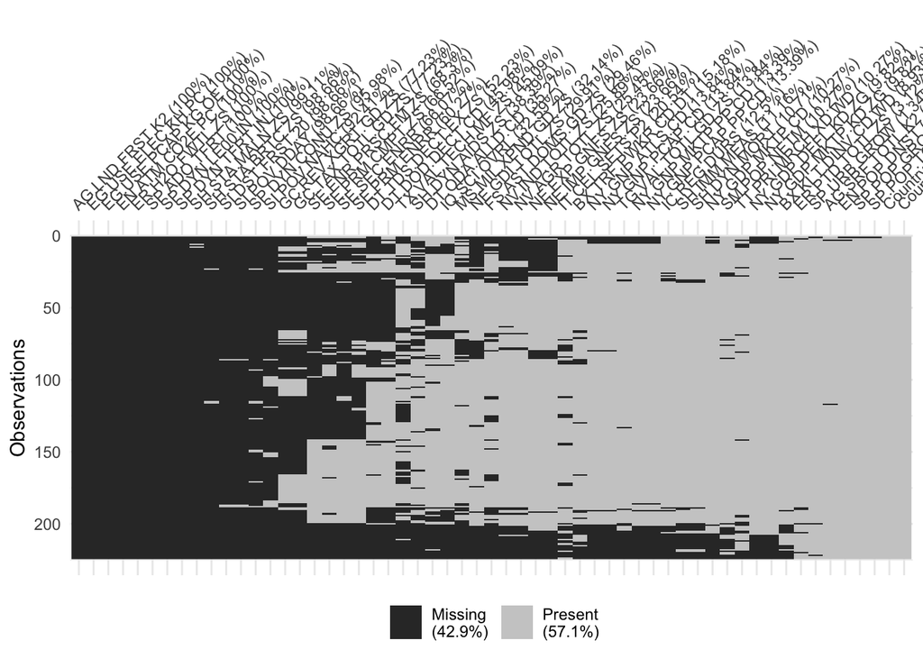

   | n | evl | p |
   | --- | --- | --- |
   | 1 | 7.47 | 0.23 |
   | 2 | 5.53 | 0.17 |
   | 3 | 2.34 | 0.07 |
   | 4 | 2.28 | 0.07 |
   | 5 | 1.84 | 0.06 |
   | 6 | 1.64 | 0.05 |
   | 7 | 1.41 | 0.04 |
   | 8 | 1.24 | 0.04 |

5. (2)Make a scree plot. How many principal components would be suggested? What proportion of variation would be explained by your choice? Please explain your thinking and decisions.

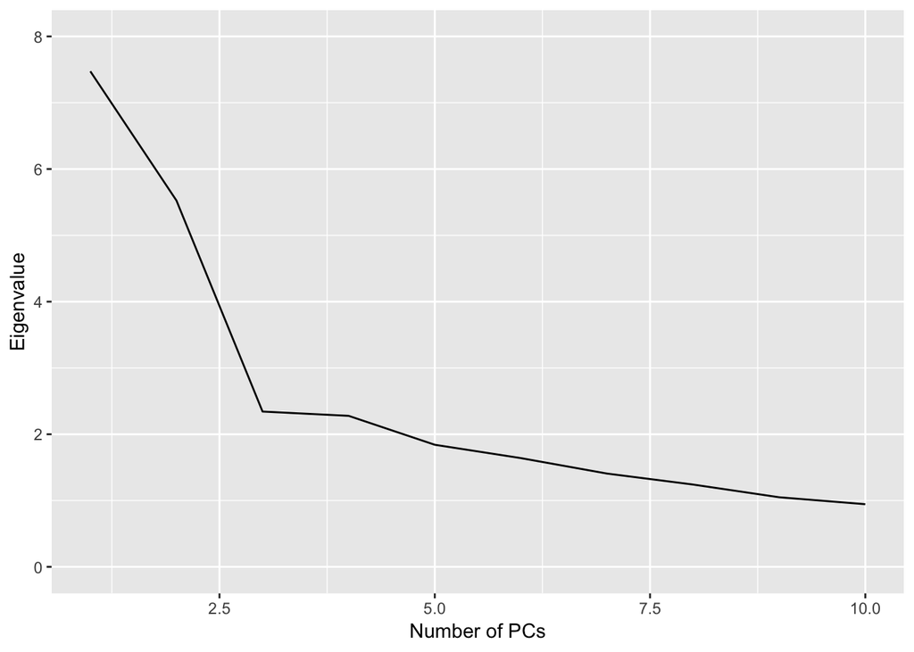

**Three PCs would be suggested by the scree plot, and this would explain 48% of the variation.**

6. (2)Make a biplot of the first two principal components, and explain the contributions of the variables, and similarity of the variables.

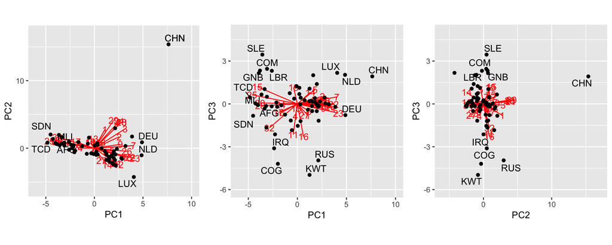

7. (2)Examine the largest coefficients for the first three principal components. Explain and interpret the first three principal components.

```
## # A tibble: 7 x 4
##   variable varname           PC1 `Series Name`
##   <chr>    <chr>           <dbl> <chr>
## 1 25       SH.DYN.MORT    -0.309 Mortality rate, under-5 (per 1,000 live b…
## 2 15       NV.AGR.TOTL.ZS -0.273 Agriculture, forestry, and fishing, value…
## 3 30       SP.URB.GROW    -0.254 Urban population growth (annual %)
## 4 28       SP.POP.GROW    -0.253 Population growth (annual %)
## 5 22       NY.GNP.PCAP.CD  0.247 GNI per capita, Atlas method (current US$)
## 6 7        FS.AST.DOMS.G…  0.270 Domestic credit provided by financial sec…
## 7 23       NY.GNP.PCAP.P…  0.279 GNI per capita, PPP (current internationa…
```

```
## # A tibble: 6 x 4
##   variable varname             PC2 `Series Name`
##   <chr>    <chr>             <dbl> <chr>
## 1 1        AG.SRF.TOTL.K2    0.251 Surface area (sq. km)
## 2 3        BX.TRF.PWKR.CD.DT 0.261 Personal remittances, received (current…
## 3 20       NY.GNP.ATLS.CD    0.350 GNI, Atlas method (current US$)
## 4 18       NY.GDP.MKTP.CD    0.350 GDP (current US$)
## 5 21       NY.GNP.MKTP.PP.CD 0.363 GNI, PPP (current international $)
## 6 29       SP.POP.TOTL       0.373 Population, total
```

```
## # A tibble: 5 x 4
##   variable varname           PC3 `Series Name`
##   <chr>    <chr>           <dbl> <chr>
## 1 16       NV.IND.TOTL.ZS -0.489 Industry (including construction), value …
## 2 11       MS.MIL.XPND.G… -0.457 Military expenditure (% of GDP)
## 3 32       TT.PRI.MRCH.X… -0.357 Net barter terms of trade index (2000 = 1…
## 4 19       NY.GDP.MKTP.K…  0.247 GDP growth (annual %)
## 5 15       NV.AGR.TOTL.ZS  0.257 Agriculture, forestry, and fishing, value…
```

**I chose an arbitrary cut off of 0.24 to indicate the largest coefficients. Technically, significant coefficients would be roughly anything larger than 1/p, but this would generate too many variables to examine.**

**PC1 may be an indicator for development, because it contrasts mortality, rural industry, population, against income. High values indicate high development (eg China, Germany, Netherlands), and low values less development (eg Sierra Leone, Sudan, Chad).**

**PC2 and PC3 are harder to explain. PC2 is a combination of land area, population, and GDP indicators.It basically indicates China is different from all other countries. PC3 is a contrast of trade, industry and military against GDP growth and rural. On one extreme is Kuwait, Congo, Russia and Iraq against Sierra Leone, Comoros, Liberia, Guinea-Bissau.**

8. (2)Several countries stand out as outliers on the biplots. Examine the principal component scores for the first three principal components. Identify the countries that are at the extremes of each, and explain what their characteristics are. Make a plot to support your arguments.

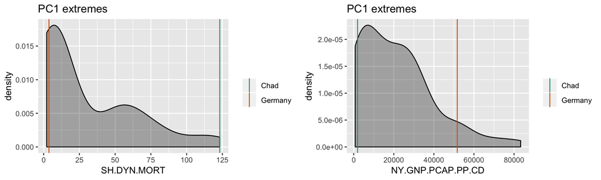

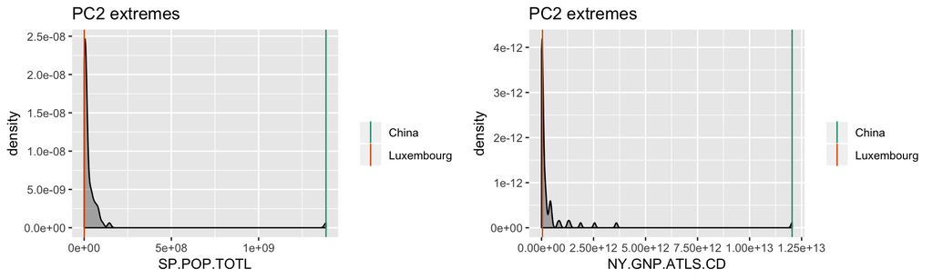

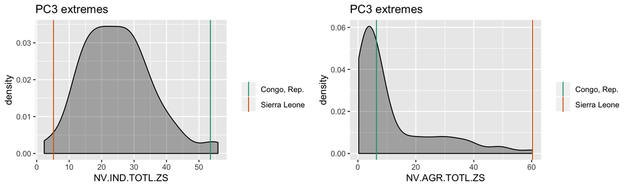

**On PC2 Luxembourg has low scores, and China has high scores. China is a heavily populated, large country with a high GNP, and the reverse is true for Luxembourg.**

**Congo has low scores on PC3 and Sierra Leone has high scores. Congo has a large proportion of GDP due to industry, and low due to agriculture, and looks to be an African powerhouse. This is a bit surprising, but reading about Congo (on wikipedia) indicates that it is about to boom as one of the few cobalt producers in the world, essential for lithium batteries in electric vehicles. They say it is the “Saudia Arabia of the electric vehicle age”. Sierra Leone is relatively non-industrial, and primarily agricultural.**

1. (2)Use bootstrap, resampling the countries to produce 95% confidence intervals for the coefficients on PC1. Revise your interpretation of PC1 based on significance of the coefficients.

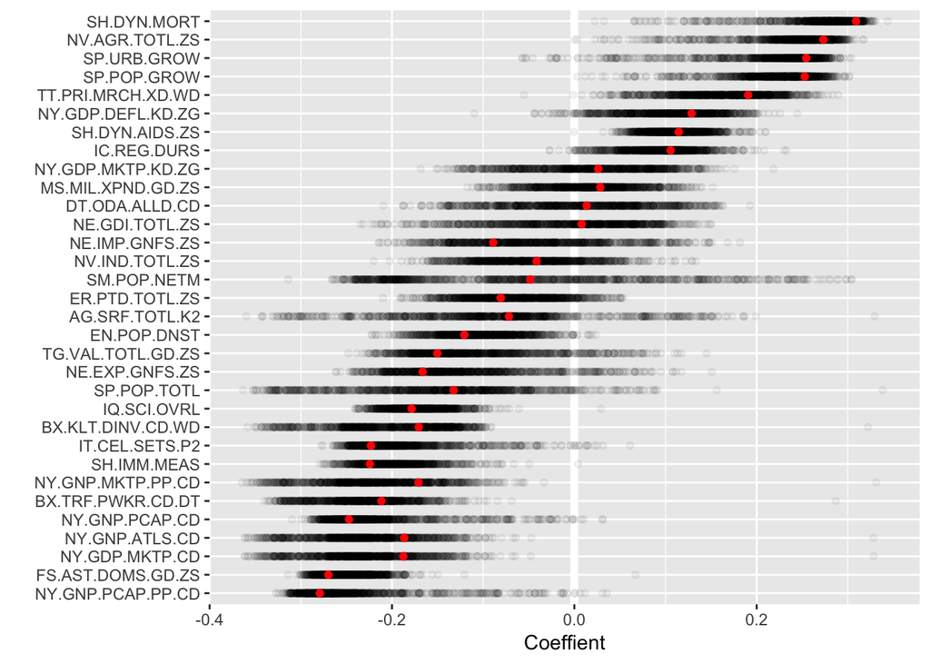

**The direction of the eigenvector needs to be fixed to one of the larger variables. I’ve used SH.DYN.MORT. Several of the variables have significant coefficients, for PC1. PC1 would still be interpreted similarly, it is basically financially wealthy, (plus good statistical capacity, and imunization program), against population growth, high mortality and prevalence of AIDS.**

(*Dotplots are better than the confidence intervals because if there is a conflict in signs it shows up in bimodality in the distribution of the coefficients.* *Interestingly, the coefficients are more stable in the bootstrapping if China is removed, because it has a high influence on the PCA. Also PC3 would be dropped with the bootstrap analysis because no variable has a coefficient substantially different from 0.*)

10. (1)True or false. *Principal* has the same meaning as *principle*. **FALSE**